# Оценка объема речного стока в Южной Калифорнии

Рева В.А.

8/6/2020

## Введение

Жители Южной Калифорнии в течение многих лет страдают от нехватки пресной воды. По данным некоторых авторов общий расход пресной воды в домах жителей Ю.Калифорнии сопоставим с таковым в Южном Судане, Руанде и Чаде. В отличие от последних сенатор от Ю.Калифорнии инициировал проект по анализу уровня осадков и запасов пресной воды в целом. Одним из важных источников пресной воды являются зимние осадки, которые могут оказывать влияние на речной сток (BSAAM), определяющий расход пресной воды в регионе в целом. Мы предположили, что существует взаимосвязь между уровнем зимних осадков и речным стоком. Для проверки этой гипотезы проведено настоящее исследование.

## Материалы и методы

В период с 1948 по 1990 гг. проводили замеры зимних осадков в разных областях Ю.Калифорнии и оценивали общий речной сток в эти же годы. Сбор данных производили в программе Excel (Microsoft). Статистическую обработку данных проводили в программе R (версия 4.0.0, The R Foundation for Statistical Computing) [1] с использованием пакетов ggplot2, car, cowplot, dplyr.

```r
# Необходимые пакеты
library(ggplot2) #для построения графиков [2]
library(car)     #для построения квантильных графиков [3]
library(readxl)  #для работы с исходным файлом .xlsx [1]
library(cowplot) #для построения нескольких графиков в одном окне [4]
library(dplyr)   #для категоризации выборок [5]
library(carData)
theme_set(theme_bw())
```

В результате исследования получены данные, представленные в таблице (датафрейме) из файла “water.xlsx”

```r
water <- read_excel ("CourseProject_water.xlsx") #команда открытия файла
```

Структуру данных оцениваем с помощью команды

```r
str(water)
```

```
## tibble [43 × 8] (S3: tbl_df/tbl/data.frame)
##  $ Year   : num [1:43] 1948 1949 1950 1951 1952 ...
##  $ APMAM  : num [1:43] 9.13 5.28 4.2 4.6 7.15 9.7 5.02 6.7 10.5 9.1 ...
##  $ APSAB  : num [1:43] 3.58 4.82 3.77 4.46 4.99 5.65 1.45 7.44 5.85 6.13 ...
##  $ APSLAKE: num [1:43] 3.91 5.2 3.67 3.93 4.88 4.91 1.77 6.51 3.38 4.08 ...
##  $ OPBPC  : num [1:43] 4.1 7.55 9.52 11.14 16.34 ...
##  $ OPRC   : num [1:43] 7.43 11.11 12.2 15.15 20.05 ...
##  $ OPSLAKE: num [1:43] 6.47 10.26 11.35 11.13 22.81 ...
##  $ BSAAM  : num [1:43] 54235 67567 66161 68094 107080 ...
```

Данные в таблице описывают ежегодные замеры зимних осадков в разных регионах и общий речной сток за те же годы. Данные представлены таблицей 43х8. Соответственно все параметры (уровень осадков в разных регионах) измерены за 43 года в 6 регионах.

Выясняем, есть ли в датафрейме пропущенные значения

```r
sum(is.na(water))
```

```
## [1] 0
```

Пропущенных значений в таблице нет.

Смотрим на средние значения и дисперсию всех представленных переменных

```r
summary(water)
```

```
##       Year          APMAM           APSAB          APSLAKE
##  Min.   :1948   Min.   : 2.70   Min.   : 1.45   Min.   : 1.77
##  1st Qu.:1958   1st Qu.: 4.97   1st Qu.: 3.39   1st Qu.: 3.36
##  Median :1969   Median : 7.08   Median : 4.46   Median : 4.62
##  Mean   :1969   Mean   : 7.32   Mean   : 4.65   Mean   : 4.93
##  3rd Qu.:1980   3rd Qu.: 9.12   3rd Qu.: 5.68   3rd Qu.: 5.83
##  Max.   :1990   Max.   :18.08   Max.   :11.96   Max.   :13.02
##      OPBPC           OPRC          OPSLAKE         BSAAM
##  Min.   : 4.0   Min.   : 4.35   Min.   : 4.6   Min.   : 41785
##  1st Qu.: 8.0   1st Qu.: 7.88   1st Qu.: 8.7   1st Qu.: 59857
##  Median : 9.6   Median :11.11   Median :12.1   Median : 69177
##  Mean   :12.8   Mean   :12.00   Mean   :13.5   Mean   : 77756
##  3rd Qu.:16.5   3rd Qu.:14.97   3rd Qu.:16.9   3rd Qu.: 92206
##  Max.   :43.4   Max.   :24.85   Max.   :33.1   Max.   :146345
```

Характер распределения данных оценивали визуально путем построения графиков

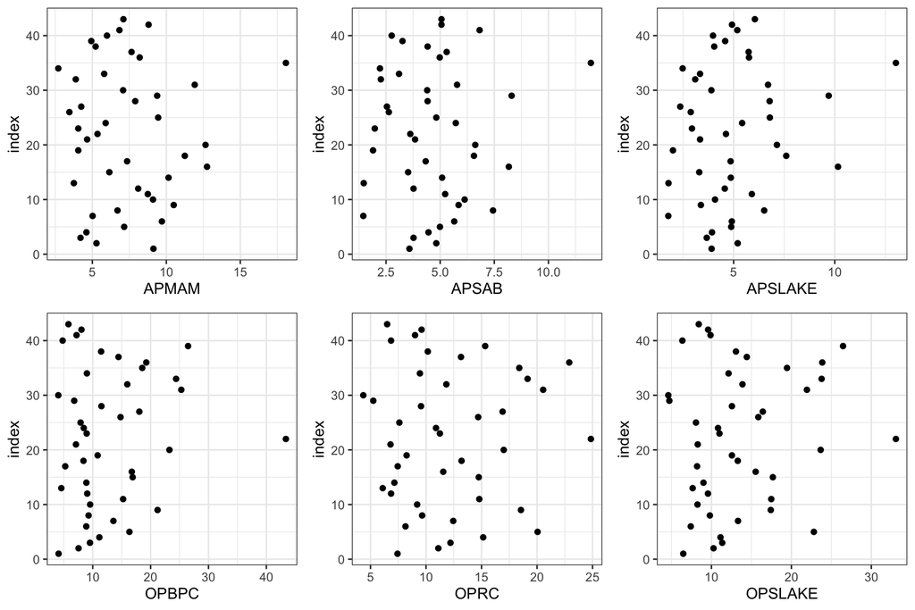

```r
set.seed(2856) #генерируем случайное число

## Ищем выбросы: диаграммы Кливленда для всех переменных (рис. 1)
gg_dot <- ggplot(water, aes(y = 1:nrow(water))) + geom_point() + ylab('index')
Pl1 <- gg_dot + aes(x = APMAM)
Pl2 <- gg_dot + aes(x = APSAB)
Pl3 <- gg_dot + aes(x = APSLAKE)
Pl4 <- gg_dot + aes(x = OPBPC)
Pl5 <- gg_dot + aes(x = OPRC)
Pl6 <- gg_dot + aes(x = OPSLAKE)
plot_grid(Pl1, Pl2, Pl3, Pl4, Pl5, Pl6, ncol = 3)
```

Видны выбросы почти во всех выборках, что может негативно сказаться на информативности модели, поэтому с помощью построения диаграмм Кливленда выявляем, а затем удаляем эти выбросы.

```r
# Удаляем выбросы, выявленные путем построения диаграмм Кливленда
water2 <- water [ which (water$APMAM <15 & water$APSAB<10 & water$APSLAKE<8 & water$OPBPC<30 & water$OPSLAKE <30),]
```

Строим новые диаграммы Кливленда для всех переменных (рис.2):

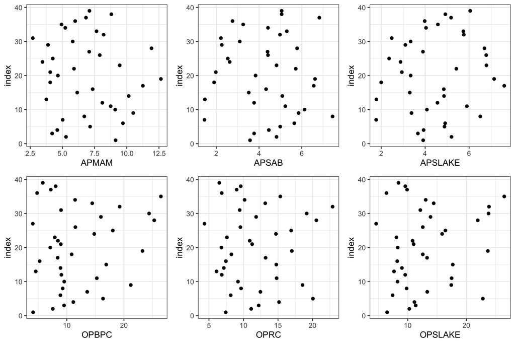

```r
gg_dot <- ggplot(water2, aes(y = 1:nrow(water2))) + geom_point() + ylab('index')
Pl1 <- gg_dot + aes(x = APMAM)
Pl2 <- gg_dot + aes(x = APSAB)
Pl3 <- gg_dot + aes(x = APSLAKE)
Pl4 <- gg_dot + aes(x = OPBPC)
Pl5 <- gg_dot + aes(x = OPRC)
Pl6 <- gg_dot + aes(x = OPSLAKE)
plot_grid(Pl1, Pl2, Pl3, Pl4, Pl5, Pl6,ncol = 3)
```

Выбросы удалены. Далее оцениваем характер связи между зависимой переменной и предикторами (рис.3).

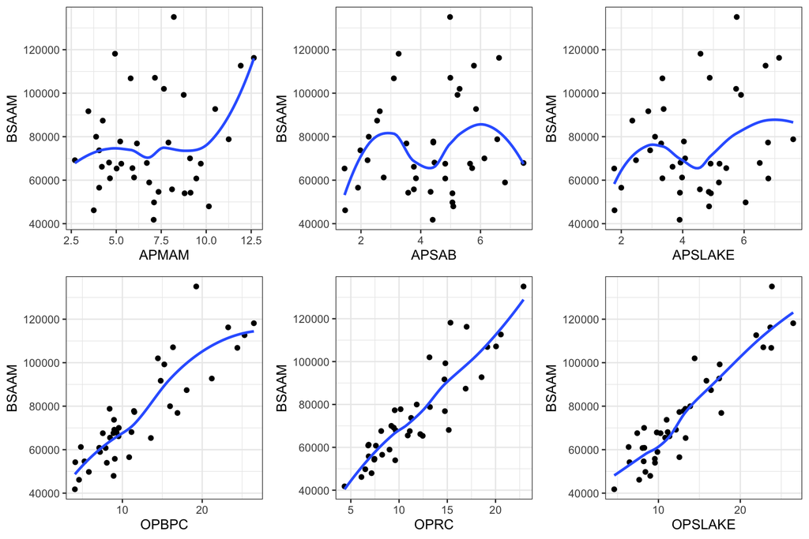

```r
gg_cor <- ggplot(water2, aes(y = BSAAM)) + geom_point() + geom_smooth(se = FALSE)
Pl1 <- gg_cor + aes(x = APMAM)
Pl2 <- gg_cor + aes(x = APSAB)
Pl3 <- gg_cor + aes(x = APSLAKE)
Pl4 <- gg_cor + aes(x = OPBPC)
Pl5 <- gg_cor + aes(x = OPRC)
Pl6 <- gg_cor + aes(x =  OPSLAKE)
plot_grid(Pl1, Pl2, Pl3, Pl4, Pl5, Pl6, ncol = 3)
```

#**Рис.3.** Графики зависимостей речного стока (BSAAM) от предикторов (уровень зимних осадков в разных регионах). Видна линейная зависимость нижних графиков и нелинейная зависимость верхних. . Выявлено, что связь между APMAM, APSAB и APSLAKE нелинейна по отношению с BSAAM, что нарушает условие применимости линейной модели. С целью стандартизации данных выполнены различные линеаризующие преобразования данных трех переменных (включая извлечение корня, возведение в квадрат, логарифмирование и др.).

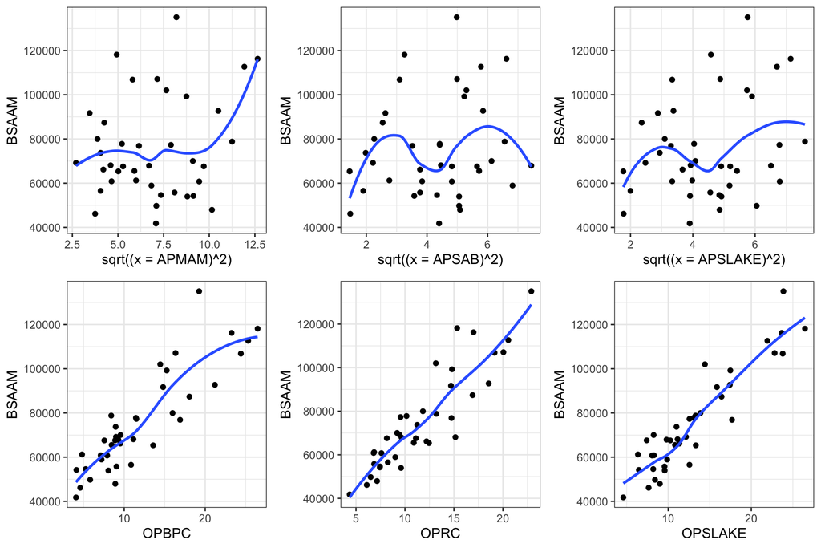

```r
# Характер связи между зависимой переменной и предикторами с преобразованными переменными APMAM, APSAB и APSLAKE с помощью sqrt(x2) (рис.4):
gg_cor <- ggplot(water2, aes(y = BSAAM)) + geom_point() + geom_smooth(se = FALSE)
Pl1 <- gg_cor + aes(sqrt((x = APMAM)^2))
Pl2 <- gg_cor + aes(sqrt((x = APSAB)^2))
Pl3 <- gg_cor + aes(sqrt((x = APSLAKE)^2))
Pl4 <- gg_cor + aes(x = OPBPC)
Pl5 <- gg_cor + aes(x = OPRC)
Pl6 <- gg_cor + aes(x =  OPSLAKE)
plot_grid(Pl1, Pl2, Pl3, Pl4, Pl5, Pl6, ncol = 3)
```

Строим модель множественной линейной регрессии

```r
water_mod <- lm(BSAAM ~ APMAM + OPBPC + OPRC + OPSLAKE, data = water2)
```

## Расчеты

Проверяем все условия применимости линейных моделей:

```r
# Проверяем на мультиколлинеарность построенную модель путем оценки фактора инфляции дисперсии (VIF)
vif(water_mod)
```

```
##   APMAM   OPBPC    OPRC OPSLAKE
##    1.05    8.94    5.32   12.11
```

```r
#Несколько предикторов избыточны (VIF > 3)
# Удаляем из модели OPSLAKE как наиболее избыточный предиктор
new_mod <- update(water_mod, ~.-OPSLAKE)

# снова проверяем на мультиколлинеарность
vif(new_mod)
```

```
## APMAM OPBPC  OPRC
##  1.03  3.86  3.85
```

```r
# Удаляем из модели OPBPC как наиболее избыточный предиктор
new_mod2 <- update(new_mod, ~.-OPBPC)

# снова проверяем на мультиколлинеарность
vif(new_mod2)
```

```
## APMAM  OPRC
##  1.02  1.02
```

```r
# создаем новую модель уже без мультиколлинеарности
final_mod <- lm(BSAAM ~ APMAM + OPRC, data = water2)

## Записываем уравнение множественной регрессии с помощью коэффициентов регрессии
coef(final_mod)
```

```
## (Intercept)       APMAM        OPRC
##       20491         578        4361
```

Полученное уравнение множественной регрессии: BSAAMfitted = 20491 + 578*APMAM + 4361*OPRC

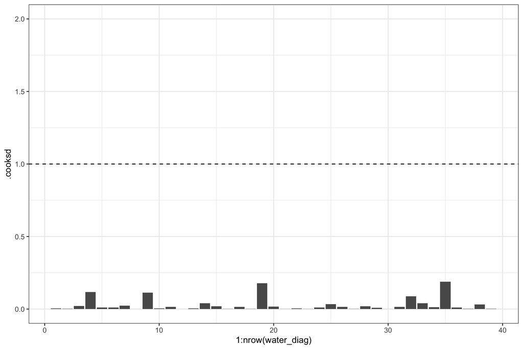

```r
# Проводим анализ остатков
water_diag <- fortify(final_mod)

# Строим график расстояний Кука (рис. 5):
ggplot(water_diag, aes(x = 1:nrow(water_diag), y = .cooksd)) +
  geom_bar(stat = 'identity') + coord_cartesian(ylim = c(0, 2)) +
  geom_hline(yintercept = 1, linetype = 2)
```

#**Рис.5.** График расстояний Кука, демонстрирующий отсутствие влиятельных наблюений.

Влиятельных наблюдений нет.

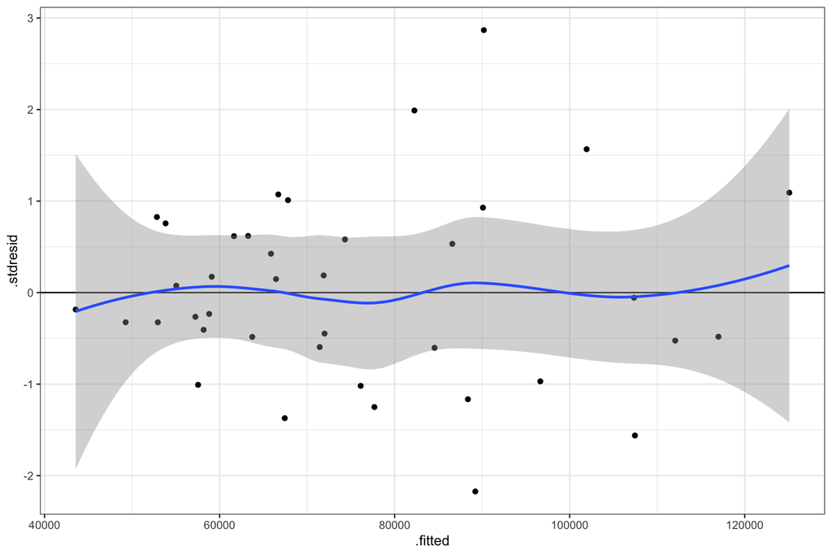

```r
# Строим график остатков от предсказанных значений (рис. 6):
gg_resid <- ggplot(data = water_diag, aes(x = .fitted, y = .stdresid)) +
  geom_point() + geom_hline(yintercept = 0) + geom_smooth()
gg_resid
```

#**Рис.6.** График остатков от предсказанных значений, демонстрирующий отсутствие выбросов и гетерогенности дисперсии остатков.

Выбросов нет. Гетерогенность дисперсии не выявляется.

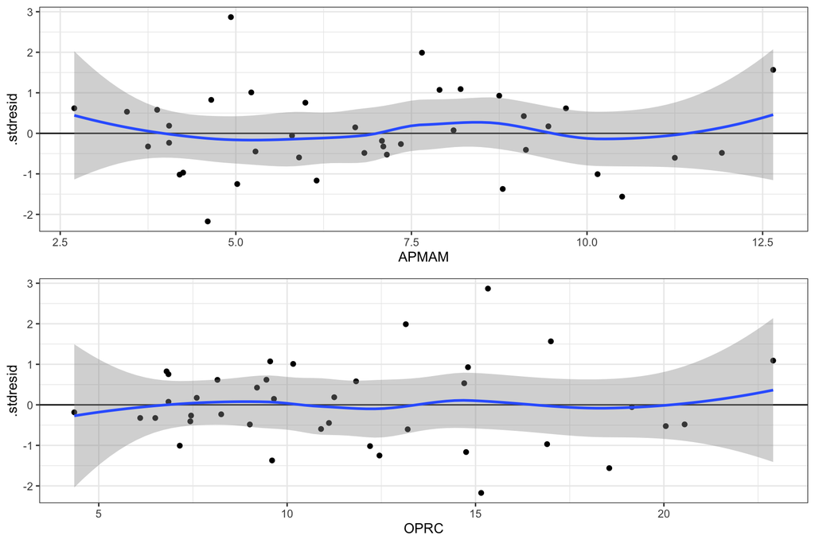

```r
## Графики зависимости остатков от предикторов в модели (рис. 7):
res_1 <- gg_resid + aes(x = APMAM)
res_2 <- gg_resid + aes(x = OPRC)

plot_grid(res_1, res_2, nrow = 2)
```

#**Рис.7.** Графики зависимости остатков от предикторов в регрессионной модели (А - от предиктора APMAM, B - от предиктора OPRC).

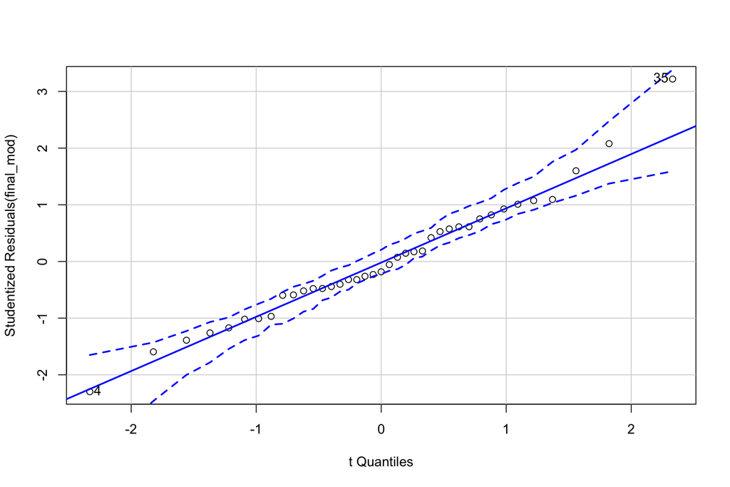

```
## [1]  4 35
```

```r
## Квантильный график остатков
qqPlot(final_mod)
```

#**Рис.8.** Квантильный график остатков, демонстрирующий их нормальное распределение. Отклонений от нормального распределения нет.

С помощью частного F-критерия оцениваем разницу объясненной дисперсии между моделями, т.е. насколько уменьшенная модель хуже нашей полной модели final_mod

```r
final_mod_APMAM <- update(final_mod, .~ .-APMAM)
anova(final_mod_APMAM, final_mod)
```

```
## Analysis of Variance Table
##
## Model 1: BSAAM ~ OPRC
## Model 2: BSAAM ~ APMAM + OPRC
##   Res.Df        RSS Df Sum of Sq    F Pr(>F)
## 1     37 3733784061
## 2     36 3654484673  1  79299388 0.78   0.38
```

Получаем, что модель незначимо меняется при удалении предиктора APMAM. Повторяем то же самое с предиктором OPRC:

```r
final_mod_OPRC <- update(final_mod, .~. - OPRC)
anova(final_mod_OPRC, final_mod)
```

```
## Analysis of Variance Table
##
## Model 1: BSAAM ~ APMAM
## Model 2: BSAAM ~ APMAM + OPRC
##   Res.Df         RSS Df   Sum of Sq   F            Pr(>F)
## 1     37 18616786242
## 2     36  3654484673  1 14962301569 147 0.000000000000027 ***
## ---
## Signif. codes:  0 '***' 0.001 '**' 0.01 '*' 0.05 '.' 0.1 ' ' 1
```

Модель значимо ухудшается. Проверяем еще раз значимость предикторов при помощи функции drop1()

```r
drop1(final_mod, test = 'F')
```

```
## Single term deletions
##
## Model:
## BSAAM ~ APMAM + OPRC
##        Df   Sum of Sq         RSS AIC F value            Pr(>F)
## <none>                 3654484673 722
## APMAM   1    79299388  3733784061 721    0.78              0.38
## OPRC    1 14962301569 18616786242 783  147.39 0.000000000000027 ***
## ---
## Signif. codes:  0 '***' 0.001 '**' 0.01 '*' 0.05 '.' 0.1 ' ' 1
```

Предиктор APMAM оказывает незначимое влияние на модель, значит, в нашей итоговой модели остается только один предиктор OPRC

```r
water_final_mod <- lm (BSAAM ~ OPRC, data = water2)
```

Смотрим на значения коэффициентов:

```r
summary (water_final_mod)
```

```
##
## Call:
## lm(formula = BSAAM ~ OPRC, data = water2)
##
## Residuals:
##    Min     1Q Median     3Q    Max
## -22627  -5294  -1540   6252  26629
##
## Coefficients:
##             Estimate Std. Error t value           Pr(>|t|)
## (Intercept)    23908       4438    5.39 0.0000042482381337 ***
## OPRC            4410        354   12.47 0.0000000000000082 ***
## ---
## Signif. codes:  0 '***' 0.001 '**' 0.01 '*' 0.05 '.' 0.1 ' ' 1
##
## Residual standard error: 10000 on 37 degrees of freedom
## Multiple R-squared:  0.808,  Adjusted R-squared:  0.803
## F-statistic:  155 on 1 and 37 DF,  p-value: 0.00000000000000817
```

## Результаты

Путем последовательного анализа данных и применения линейной регрессии с соблюдением условий ее применимости построена итоговая регрессионная модель зависимости речного стока от уровня зимних осадков: BSAAMfitted = 23908 + 4410*OPRC Данная модель статистически значима. Выявлено, что результаты анализа уровня зимних осадков в регионе OPRC статистически значимо связаны с речным стоком BSAAM (t0.05, 37 = 12.47, p <0.0001).

Произведена визуализация модели (рис. 9)

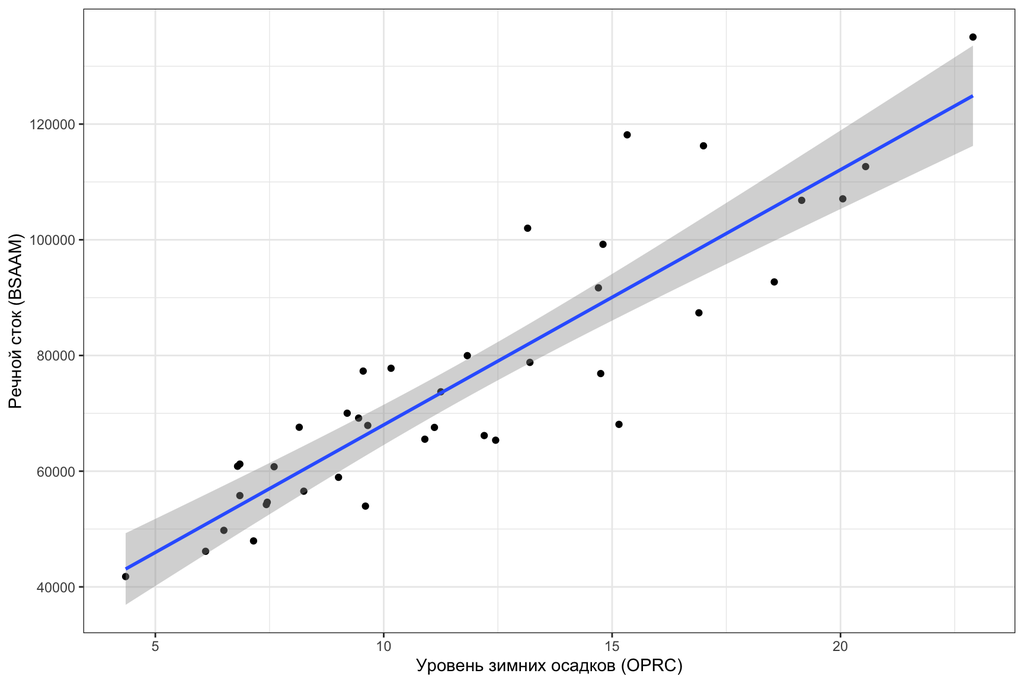

```r
ggplot(water2, aes (x = OPRC, y = BSAAM)) + geom_point() + labs (x = 'Уровень зимних осадков (OPRC)', y = 'Речной сток (BSAAM)') + geom_smooth (method = 'lm')
```

#**Рис.9.** График зависисимости речного стока от уровня зимних осадков демонстрирует линейную положительную зависимость. Имеется линейная положительная зависимость между предиктором и откликом. Данная модель хорошо описывает исходные данные: r2 = 0.80 (80% изменчивости).

Выполнено построение графика предсказаний модели (рис. 10):

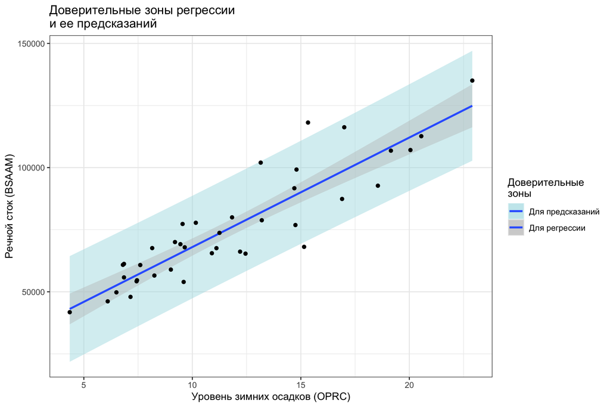

```r
water_predicted <- predict (water_final_mod, interval = 'prediction')
water_predicted <- data.frame (water2, water_predicted)
fitted_mod <- ggplot (water_predicted, aes (x = OPRC, y = BSAAM)) + geom_ribbon (aes(ymin = lwr, ymax = upr, fill = 'Для предсказаний'), alpha = 0.5) + geom_smooth (method = 'lm', aes (fill = 'Для регрессии')) + scale_fill_manual (name = 'Доверительные \nзоны', values = c ('powderblue', 'gray')) + geom_point () + labs (x = 'Уровень зимних осадков (OPRC)', y = 'Речной сток (BSAAM)', title = 'Доверительные зоны регрессии \nи ее предсказаний')
fitted_mod
```

#**Рис.10.** График предсказаний регрессионной модели и доверительной зоны регрессии показывает, что большинство значений переменной OPRC укладывается в предсказанные регрессионной моделью значения, что говорит о хорошем подборе модели.

## Список литературы

[1] RStudio Team (2020). RStudio: Integrated Development for R. RStudio, PBC, Boston, MA URL http://www.rstudio.com/.

[2]. Wickham, H. (2016). ggplot2: elegant graphics for data analysis. Springer.

[3] Fox J, Weisberg S (2019). An R Companion to Applied Regression, Third edition. Sage, Thousand Oaks CA. https://socialsciences.mcmaster.ca/jfox/Books/Companion/.

[4] Wilke CO. https://www.rdocumentation.org/packages/cowplot

[5] Wickham H, François R, Henry L, Müller K. (2020). dplyr: A Grammar of Data Manipulation. R package version 1.0.0. https://CRAN.R-project.org/package=dplyr